# 36-315 Homework 05, Spring 2017

Sample Solutions

Due Wednesday, February 22, 2017 (12pm ET) on Blackboard

## Homework 05: Density Estimates, Histograms, and Parameter Selection

*General instructions for all assignments*:

- Use this file as the template for your submission. Delete the unnecessary text (e.g. this text, the problem statements, etc). That said, keep the nicely formatted “Problem 1”, “Problem 2”, “a.”, “b.”, etc
- Upload a single `R` Markdown file (named as: [AndrewID]-HW05.Rmd – e.g. “sventura-HW05.Rmd”) to the Homework 05 submission section on Blackboard. You do not need to upload the .html file.
- The instructor and TAs will run your .Rmd file on their computers. **If your .Rmd file does not knit on our computers, you will be automatically be deducted 10 points.**
- Your file should contain the code to answer each question in its own code block. Your code should produce plots/output that will be automatically embedded in the output (.html) file
- Each answer must be supported by written statements (unless otherwise specified)
- Include the name of anyone you collaborated with at the top of the assignment
- Include the style guide you used below under Problem 0

# Problem 0

**Style Guide and Tabbed HTML Output**

1. What style guide are you using on this assignment? (Up to 10 points will be deducted if you do not adhere to a specific style guide.)
2. Remember to include a floating table of contents in your submission.

# Problem 1

(5 points)

**Build your #brand**

```r
#Create theme that can be added to plots
library(tidyverse)
library(gridExtra)
my_theme <-  theme_bw() + # White background, black and white theme
  theme(axis.text = element_text(size = 12, color = "indianred4"),
        text = element_text(size = 14, face = "bold", color = "darkslategrey"))
```

## Load the Food Facts Data

**Load the Food Facts dataset into R.** This is a carefully chosen, modified subset of the data provided [here](https://www.kaggle.com/openfoodfacts/world-food-facts) by Kaggle. Documentation for all of the variables is available at that link as well.

The Food Facts data is available on the Course GitHub page [here](https://raw.githubusercontent.com/sventura/315-code-and-datasets/master/data/food-facts.csv).

When you read it into `R`, store it in an object called `food`, then complete the following problems.

```r
food <- read_csv("https://raw.githubusercontent.com/sventura/315-code-and-datasets/master/data/food-facts.csv")
```

# Problem 2

**Density Estimates vs. Histograms**

In this problem, we’ll examine the distribution of `energy_100g` with density estimates, histograms, and rug plots.

1. `energy_100g` is number of kilojoules (kJ) per 100 grams of food.

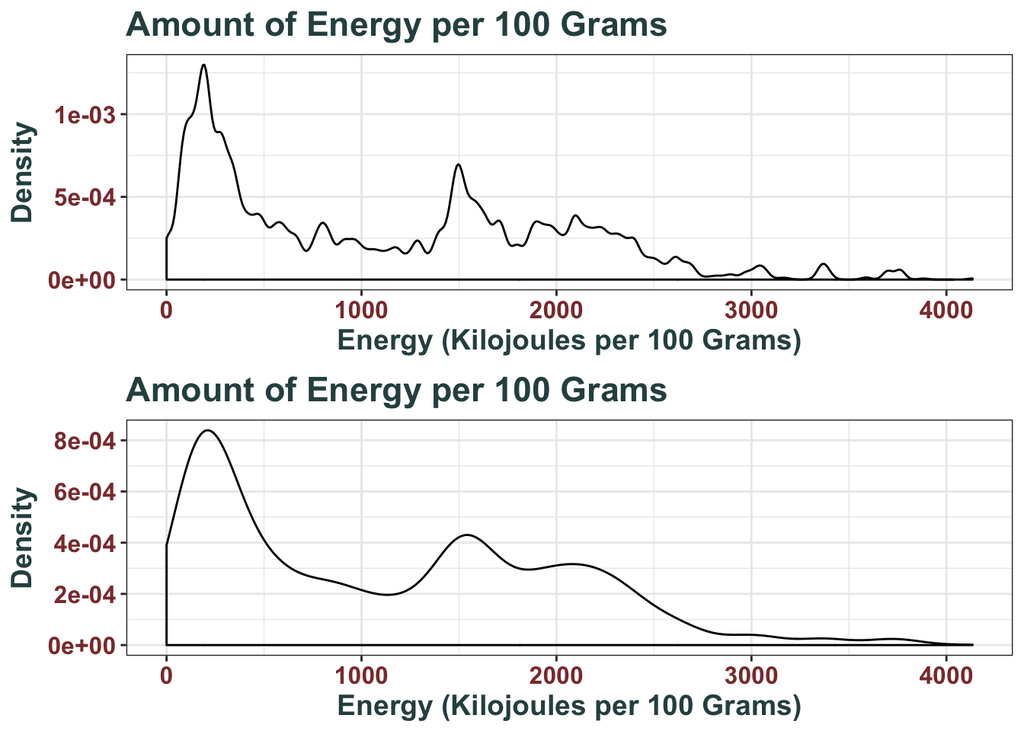

```r
density_small_bw <- ggplot(food, aes(x = energy_100g)) + geom_density(bw = 25) +
  labs(x = "Energy (Kilojoules per 100 Grams)", y = "Density",
       title = "Amount of Energy per 100 Grams") +
  my_theme


density_large_bw <- ggplot(food, aes(x = energy_100g)) + geom_density(bw = 125) +
  labs(x = "Energy (Kilojoules per 100 Grams)", y = "Density",
       title = "Amount of Energy per 100 Grams") +
  my_theme

grid.arrange(density_small_bw, density_large_bw, nrow=2)
```

Lower bandwidths make it easier to visualize local features of the distribution (small modes and valleys), while higher bandwidths make it easier to see global features (larger modes, center, spread, shape).

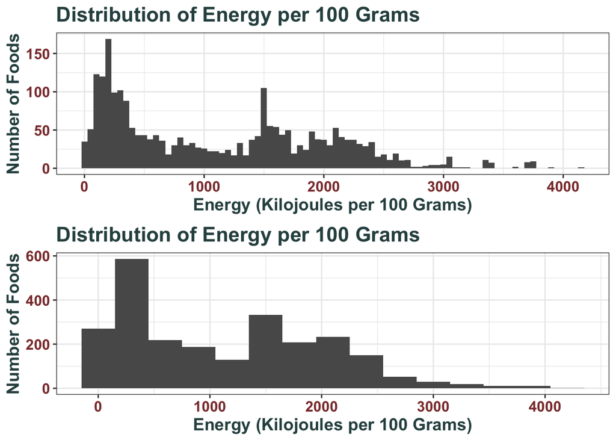

```r
hist_small_bin <- ggplot(food, aes(x = energy_100g)) +
  geom_histogram(binwidth = 50) +
  labs(x = "Energy (Kilojoules per 100 Grams)", y = "Number of Foods",
       title = "Distribution of Energy per 100 Grams") +
  my_theme

hist_larger_bin <- ggplot(food, aes(x = energy_100g)) +
  geom_histogram(binwidth = 300) +
  labs(x = "Energy (Kilojoules per 100 Grams)", y = "Number of Foods",
       title = "Distribution of Energy per 100 Grams") +
  my_theme

grid.arrange(hist_small_bin, hist_larger_bin, nrow = 2)
```

As with above, lower binwidths make it easier to visualize local features of the distribution (small modes and valleys), while larger binwidths make it easier to see global features (larger modes, center, spread).

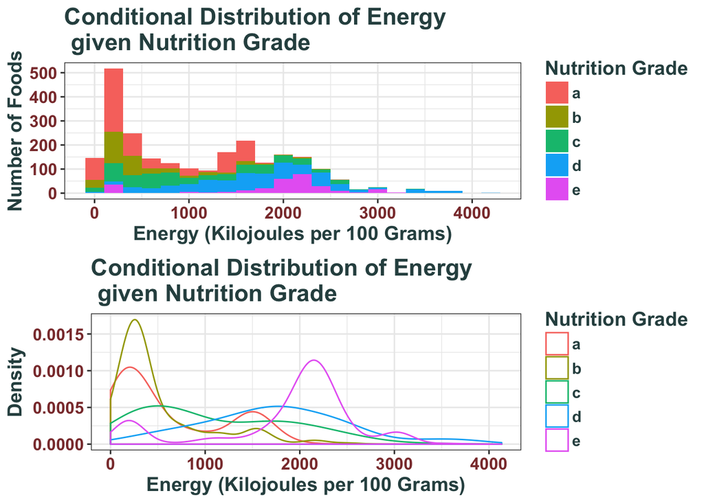

[figure not shown]

```r
stacked_hist <- ggplot(data = food, aes(energy_100g, fill = nutrition_grade_fr)) +
  geom_histogram(binwidth = 200) +
  labs(x = "Energy (Kilojoules per 100 Grams)",
       y = "Number of Foods",
       title = "Conditional Distribution of Energy \n given Nutrition Grade",
       fill = "Nutrition Grade") +
  my_theme

cond_dens <- ggplot(food, aes(x = energy_100g, color = nutrition_grade_fr)) +
  geom_density(adjust = 1.5) +
  labs(x = "Energy (Kilojoules per 100 Grams)",
       y = "Density",
       title = "Conditional Distribution of Energy \n given Nutrition Grade",
       color = "Nutrition Grade") +
  my_theme

facetted_density <- ggplot(food, aes(x = energy_100g)) +
  geom_density() +
  facet_wrap( ~ nutrition_grade_fr, ncol = 1) +
  labs (x = "Energy (Kilojoules per 100 Grams)",
        y = "Density",
        title = "Conditional Distribution of Energy \n given Nutrition Grade") +
  my_theme

grid.arrange(stacked_hist, cond_dens, nrow = 2)
```

The distribution of energy per 100 grams changes depending on nutritional grade. From the density estimates of `energy_100g` facetted on `nutrition_grade_fr`, we see that the conditional distributions for nutritional grades a, b, c are right skewed. We see that nutritional grades a, b, c and e have modes around 300 kiljoules. In addition, nutritional grades a and b have modes near 1500 kilojoules. The distribution of kilojoules for nutritional grade “d” has a mode around 1600 kilojoules and the distribution of kilojoules for nutritional grade “e” has a mode around 2100 kJ and another just above 3000 kJ.

5. It makes more sense to display the facetted density estimates in a 5x1 grid (5 rows, 1 column) because it is easier to compare the locations of the distributions on the x-axis. For example, a vertical facet would make it easy to visualize and compare modes in the conditional distributions. However, it is advantageous to facet horizontally when trying to compare features on the y-axis. In this case, the specific density values aren’t easily interpretable, so a 1x5 grid would not be ideal.

That said, you want to avoid using red and green in the same plot, since red-green colorblind viewers will not be able to distinguish the colors.

6. (3 points) Recreate the first plot from part (d), but use your own color gradient. You can use an adjusted version of the above code to do this. (Please do not include the example graph in your final submission.) You are also welcome to change the middle color (currently “grey”) to something else (e.g. “white”), or remove the middle color entirely.

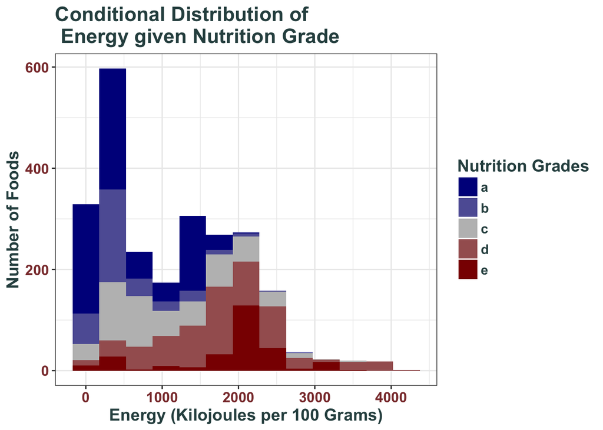

```r
color1 <- "darkblue"
color2 <- "darkred"
palette <- c(color1, "grey", color2)

 ggplot(data = food, aes(energy_100g, fill = nutrition_grade_fr)) +
  geom_histogram(binwidth = 350) +
  labs(x = "Energy (Kilojoules per 100 Grams)",
       y = "Number of Foods",
       title = "Conditional Distribution of \n Energy given Nutrition Grade") +
  scale_fill_manual(name = "Nutrition Grades",
                  values = colorRampPalette(palette)(
                    length(unique(food$nutrition_grade_fr))
                    ),
                  labels = sort(unique(food$nutrition_grade_fr)),
                  drop = FALSE) + my_theme
```

# Problem 3

1. (2 points) What information is contained in the `salt_100g` variable?

We can find documentation on the variables [here](https://world.openfoodfacts.org/data/data-fields.txt). The variable `salt_100g` correspond to the amount of salt (in grams) for 100 grams or 100 ml of product (solid vs liquid). We’ll use the notation “g per 100 g / 100 ml” for this relationship even though “/” sometimes can suggest “per”.

2. (3 points) Which countries typically have foods with higher salt content? To answer this, visualize the distribution of `salt_100g` given the `countries_en` variable with a stacked histogram. Describe the distribution. Be sure to mention center, spread, skew, and modality. What about the distribution makes it hard to answer this question?

Note: Part (b) is an example of the type of question you might see on a lab example.

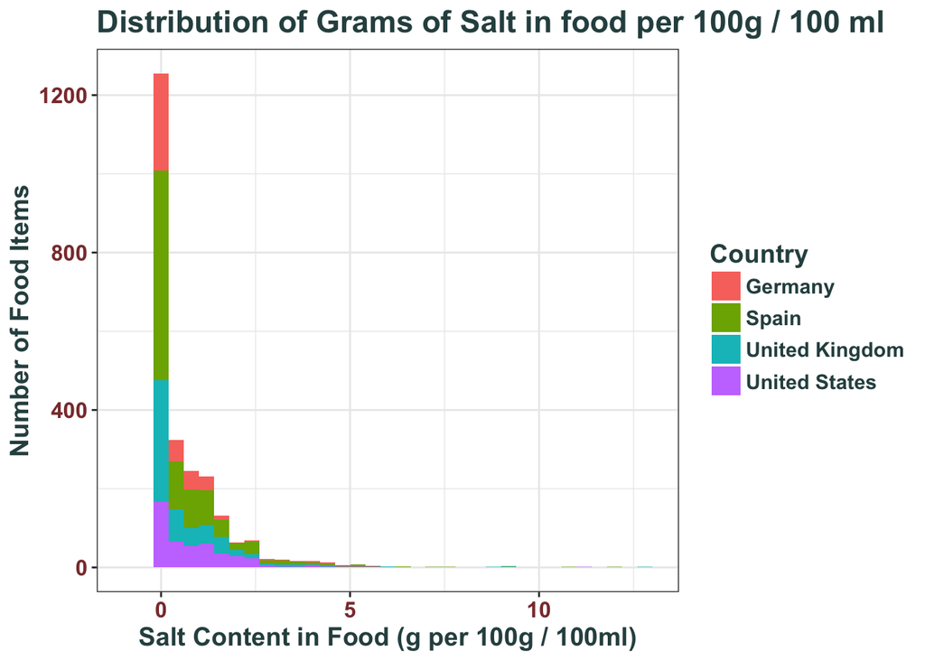

```r
b <- ggplot(food,aes(x = salt_100g,fill = countries_en)) +
  geom_histogram(binwidth = .4) + scale_x_continuous(limits = c(-1,13) ) +
  labs(title = "Distribution of Grams of Salt in food per 100g / 100 ml",
       x = "Salt Content in Food (g per 100g / 100ml)",
       y = "Number of Food Items",
       fill = "Country") + my_theme
potential_outliers <- round(tail(sort(food$salt_100g), 5), 2)
b
```

With heavily skewed distributions (especially those with an exponential shape), discussing center doesn’t make much sense. It’s more important to characterize the rate of decay. In this case, it appears that almost all of the observations (likely more than 99%) have salt content per 100g / 100ml lower than 5g.

We should be careful when discussing concepts like outliers with heavily skewed distributions as well. For example, it might be okay to consider anything over 5g to be an outlier, or maybe anything over 10g. But since there is no universally agreed-upon definition of outliers, we should be careful in our discussion here. See the .Rmd file for an example of how you can identify and print out the top 5 highest values in the dataset. The 5 highest values in this distribution are at values of 12.88, 13.79, 14.4, 17.12, and 62.23 grams of salt per 100 g / 100 ml.

3. (5 points) Visualize the log-transformed `salt_100g` variable (in `R`, the `log()` function gives the natural log by default). To do this, use `ggplot(food) + geom_histogram(aes(x = log(salt_100g)))`, and be sure to add appropriate titles and axis labels (in particular, what are the units on the x-axis?) and use a larger-than-default number of bins. Is it easier to answer the question in (b) with this graph? Are there particular countries with higher salt content in their foods?

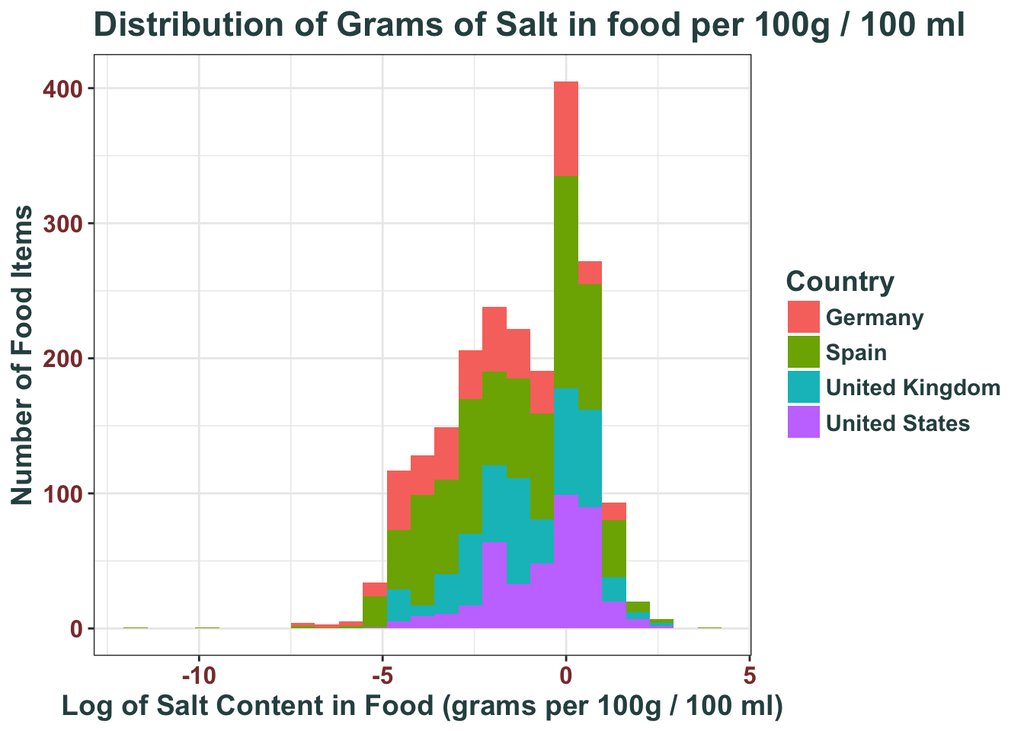

```r
c <- ggplot(food, aes(x = log(salt_100g), fill = countries_en)) +
  geom_histogram(bins = 25) +
  labs(title = "Distribution of Grams of Salt in food per 100g / 100 ml",
       x = "Log of Salt Content in Food (grams per 100g / 100 ml)",
       y = "Number of Food Items",
       fill = "Country") +
  my_theme
c
```

**A better approach to applying a log transformation to scale the data would be to apply a transformation like $log(x+1)$, and we do so below.** Using this approach, none of the obsevations are removed, and the minimum value at the log scale is zero.

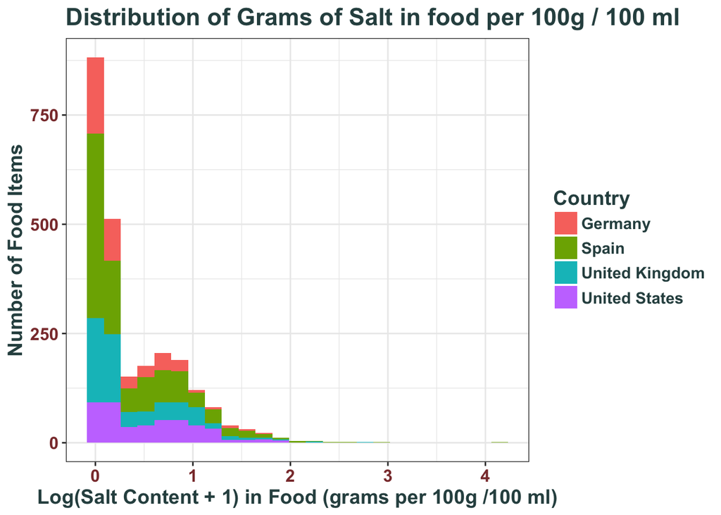

```r
c2 <- ggplot(food, aes(x = log(salt_100g + 1), fill = countries_en)) +
  geom_histogram(bins = 25) +
  labs(title = "Distribution of Grams of Salt in food per 100g / 100 ml",
       x = "Log(Salt Content + 1) in Food (grams per 100g /100 ml)",
       y = "Number of Food Items",
       fill = "Country") +
  my_theme
c2
```

In the $log(x + 1)$ transformation of salt content in food per 100 g / 100 ml, we see that the distribution has two modes – one large mode close to zero (this corresponds to observations with zero or near-zero actual grams of salt per 100g / 100ml), and one smaller mode near 0.75 at the log scale. Germany has fewer highly salty foods (foods with $log(salt + 1) > 0.8$, i.e. 1.22 grams of salt per 100 g / 100 ml). Spain tends also to have high amount of salt-free foods, but also many high-salt foods. The US appears to have the fewest salt-free foods and the highest relative proportion of high-salt foods.

**I will continue the analysis using this $log(x+1)$ transformation.**

4. (5 points) Repeat part (c), but with a conditional density estimate plot instead of a stacked histogram. Use the `adjust` parameter to reduce the bandwidth to 75% of the default value.

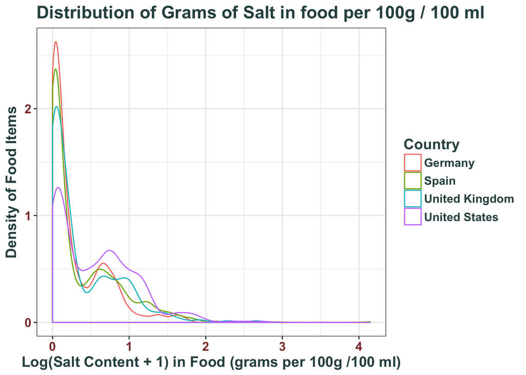

```r
ggplot(food, aes(x = log(salt_100g + 1), color =countries_en)) +
  geom_density(adjust = 0.75) +
  #scale_x_continuous(limit = c(-.1,3)) +
    labs(title = "Distribution of Grams of Salt in food per 100g / 100 ml",
       x = "Log(Salt Content + 1) in Food (grams per 100g /100 ml)",
       y = "Density of Food Items",
       color = "Country") +
  my_theme
```

The density estimates conditional on the country of production help express that the US has relatively more high-salt foods, as evidenced by the relatively large portion of the US distribution being higher than 0.5 at the log scale, and the relatively small mode near 0. The other countries don’t have a clear order on quanities of more highly salted foods, but they do in the number of foods with very low / zero grams of salt per 100 g / 100 ml, with Germany having the most of these food items (per total food items reported), followed by Spain, the UK, and the US.

5. (10 points) Examine the plots from the following lines of code. Why does the rug plot show up in some plots, but not in others? Why do the middle-column plots look different from the others? Which line of code is most efficient and appropriate to use, given how `ggplot()` uses the `aes()` function?

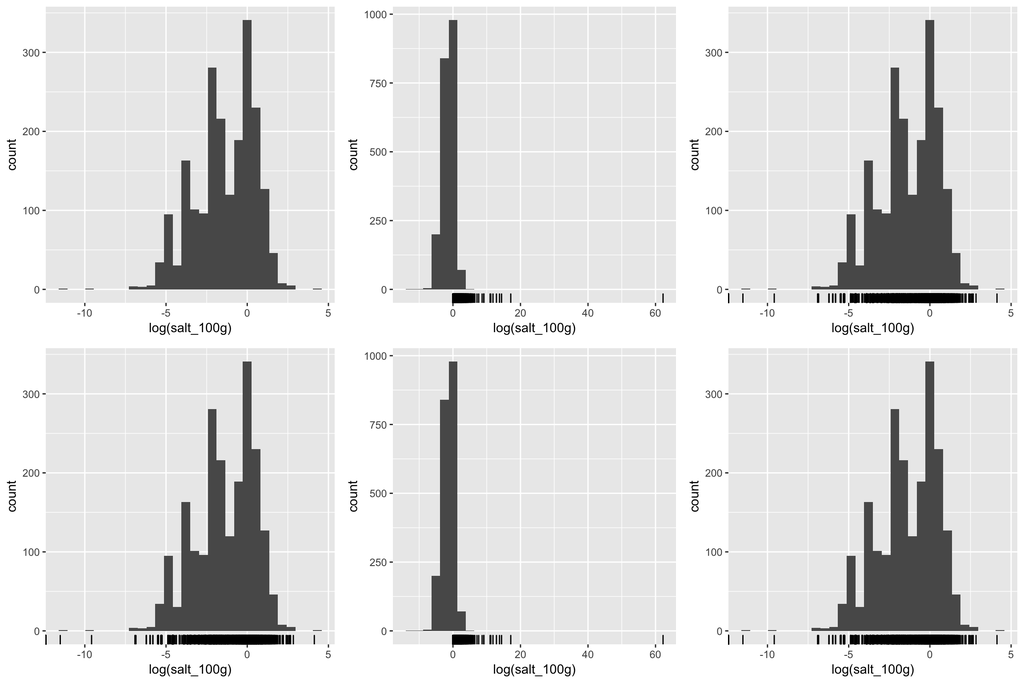

```r
library(gridExtra)
plot1 <- ggplot(food) + geom_histogram(aes(x = log(salt_100g))) + geom_rug() #doesn't show - wasn't told what x is (not passed along)
plot2 <- ggplot(food) + geom_histogram(aes(x = log(salt_100g))) + geom_rug(aes(x = salt_100g)) #should show, but is dealing with incorrect transformation of parameter
plot3 <- ggplot(food) + geom_histogram(aes(x = log(salt_100g))) + geom_rug(aes(x = log(salt_100g))) #should show, given directly
plot4 <- ggplot(food, aes(x = log(salt_100g))) + geom_histogram() + geom_rug() #should show, in initialized area
plot5 <- ggplot(food, aes(x = log(salt_100g))) + geom_histogram() + geom_rug(aes(x = salt_100g)) # should show, but overrides the transformation
plot6 <- ggplot(food, aes(x = log(salt_100g))) + geom_histogram() + geom_rug(aes(x = log(salt_100g))) #should show- overkill

grid.arrange(plot1, plot2, plot3, plot4, plot5, plot6, ncol = 3)
```

The rug plot shows up only if it is given an `salt_100g` as an `x` variable. This can happen in two ways:

- If `aes(x = log(salt_100g)` is set inside the `ggplot()` function then it is passed to `geom_rug()` since anything set in `ggplot()` is used as the default for subsequent layers.
- If `aes(x = log(salt_100g))` is not set inside the `ggplot()` but is set in `geom_rug()` then the rug plot displays that data (i.e. `salt_100g`).

To efficiently use the structure of `ggplot` with relationship to passing variables to structure via `aes` we can say that `plot4` does the best job. The other plots that work correctly (`plot3`, `plot6`) provide multiple times when we call the same `aes(x = log(salt_100g))`, which is inefficient.

6. (BONUS: 2 points) `ggplot()` has many scaling functions built in. What can you add to the following line of code (where it currently says `+ ???` to put the x-axis on the square-root scale? What about the log-base-10 scale?

`ggplot(food, aes(x = salt_100g)) + geom_histogram() + geom_rug() + ???`

For the square root, use `scale_x_sqrt()`; for log base 10, use `scale_x_log10()`.